# Genetic Nurturing Effects

Melisa Chuong

17/09/2022

# Generation Scotland Trios

Genotyped data and pedigree files can be found on datastore @/exports/igmm/eddie/GenScotDepression/data/genscot/genetics/genotypes/GS20K_PLINK_files/QCd_data  
*These files are saved as GS_QC.bed/.bim/.fam*

```r
fam <- read.table(here::here("data", "gs", "GS_QC.fam")) #this file was renamed for convenience
colnames(fam) <- c("FID", "IID", "PID", "MID", "SEX", "PHENO")

fatherpresent <- fam[fam$PID%in%fam$IID,] #Finding PIDs also present in the IID column - every individual in the IID column in the pedigree file has genotyped data#
dim(fatherpresent) #fatherduo n= 3,865
```

```
## [1] 3865    6
```

```r
motherpresent <- fam[fam$MID%in%fam$IID,] #Finding MIDs also present in the IID column#
dim(motherpresent) #motherduo n=5,954
```

```
## [1] 5954    6
```

```r
trio <- fam[fam$PID%in%fam$IID & fam$MID%in%fam$IID,] #Finding trios, i.e. individuals with both PIDs and MIDs present in the IID column#
```

n= 2680 genotyped trios available in Generation Scotland

# Phenotypes

## Covars

```r
age <- read.table(here::here("data", "gs", "GS_Ages.qcovar"), header=T)
age <- age[,c("IID", "age")]
colnames(age) <- c("IID", "AGE")

sex <- read.table(here::here("data", "gs", "GS_SexClinic.fcovar"), header=T)
sex <- sex[,c("IID", "sex")]
colnames(sex) <- c("IID", "SEX")

pcs <- read.table(here::here("data", "gs", "HM3mds.mds"), header=T)
pcs <- pcs[!pcs$FID %in% c("CEU", "CHB", "YRI", "TSI", "JPT", "CHD",
"MEX", "GIH", "ASW", "LWK", "MKK"), ] # remove reference sets
pcs$FID <- NULL
pcs$SOL <- NULL

covars <- merge(age, sex, by="IID")
covars <- merge(covars, pcs, by="IID")

covar_formula <- . ~ AGE+SEX+C1+C2+C3+C4+C5+C6+C7+C8+C9+C10+C11+C12+C13+C14+C15+C16+C17+C18+C19+C20
```

## Height

Raw Phenotype

```r
df <- load(here::here("data", "gs", "masterDB.Rdata"))
which(colnames(totaldata)=="height")
```

```
## [1] 34
```

```r
height <- totaldata[,c('id','height')]
height <- height[complete.cases(height),] #n=21,450
colnames(height) <- c("IID", "HEIGHT")
```

Trio Phenotype

```r
height_covars <- merge(height, covars, "IID")

#Regressing out the effects of AGE, SEX, and PCs
height_cov_m <- lm(update(covar_formula, HEIGHT~.), data=height_covars)
height_res <- height_covars[, c("IID", "HEIGHT")]
height_res$HEIGHT_res <- residuals(height_cov_m)

summary(height_res$HEI_res)
```

```
## Length  Class   Mode
##      0   NULL   NULL
```

```r
sd(height_res$HEI_res)
```

```
## [1] NA
```

```r
trio_height <- merge(trio, height_res, by="IID", all.x=T)
trio_height <- merge(trio_height, height_res, by.x = "MID", by.y = "IID", suffixes = c('', '_mat'))
trio_height <- merge(trio_height, height_res, by.x = "PID", by.y = "IID", suffixes = c('', '_pat'))
```

Phenotype Demographics

```r
trio_height_complete <- trio_height[complete.cases(trio_height),]
pheno_info <- c()

for(column in c('HEIGHT', 'HEIGHT_mat', 'HEIGHT_pat')){
  min_pheno <- min(trio_height_complete[column])
  max_pheno <- max(trio_height_complete[column])
  mean_pheno <- sum(trio_height_complete[column])/dim(trio_height_complete)[1]
  height_info <- Reduce(function(x,y) cbind(x=x, y=y), list(column, min_pheno, mean_pheno, max_pheno, dim(trio_height_complete)[1]))
  pheno_info <- rbind(pheno_info, height_info)
}
```

## Educational Attainment

Raw Phenotype

```r
ea <- totaldata[,c("id", "years_category")]
colnames(ea) <- c("IID", "EA")
ea <- ea[complete.cases(ea),]
```

Trios Phenotype

```r
ea_covars <- merge(ea, covars, by = "IID")
ea_covars <- ea_covars[complete.cases(ea_covars),]

#Regressing out the effects of AGE and SEX
ea_cov_m <- lm(update(covar_formula, EA~.), data=ea_covars)
ea_res <- ea_covars[, c("IID", "EA")]
ea_res$EA_res <- residuals(ea_cov_m)

summary(ea_res$EA_res)
```

```
##    Min. 1st Qu.  Median    Mean 3rd Qu.    Max.
## -5.3712 -1.2486 -0.3375  0.0000  1.1365  6.0498
```

```r
sd(ea_res$EA_res)
```

```
## [1] 1.533404
```

```r
trio_ea <- merge(trio, ea_res, by="IID", all.x=T)
trio_ea <- merge(trio_ea, ea_res, by.x = "MID", by.y = "IID", suffixes = c('', '_mat'))
trio_ea <- merge(trio_ea, ea_res, by.x = "PID", by.y = "IID", suffixes = c('', '_pat'))
```

Phenotype Demographics

```r
ea_complete <- trio_ea[complete.cases(trio_ea),]

for(column in c('EA', 'EA_mat', 'EA_pat')){
  min_pheno <- min(ea_complete[column])
  max_pheno <- max(ea_complete[column])
  mean_pheno <- sum(ea_complete[column])/dim(ea_complete)[1]
  ea_info <- Reduce(function(x,y) cbind(x=x, y=y), list(column, min_pheno, mean_pheno, max_pheno, dim(ea_complete)[1]))
  pheno_info <- rbind(pheno_info, ea_info)
}
```

## Depressive symptoms

Raw Phenotype

```r
ghq <- read.csv(here::here("data", "gs", "GS_All_GHQ.csv"))
ghq_dep <- ghq[,c("id", "GHQDepression")]
ghq_dep <- ghq_dep[complete.cases(ghq_dep),]
names(ghq_dep) <- c("IID", "GHQD")
```

Trios Phenotype

```r
ghqd_covars <- merge(ghq_dep, covars, by=c("IID")) #n=19,961

#Regressing out the effects of AGE and SEX
ghqd_cov_m <- lm(update(covar_formula, GHQD~.), data=ghqd_covars)
ghqd_res <- ghqd_covars[, c("IID", "GHQD")]
ghqd_res$GHQD_res <- residuals(ghqd_cov_m)

summary(ghqd_res$GHQD_res)
```

```
##     Min.  1st Qu.   Median     Mean  3rd Qu.     Max.
## -1.44639 -0.95763 -0.83436  0.00000 -0.05847 20.30059
```

```r
sd(ghqd_res$GHQD_res)
```

```
## [1] 2.354741
```

```r
trio_ghqd <- merge(trio, ghqd_res, by="IID", all.x=T)
trio_ghqd <- merge(trio_ghqd, ghqd_res, by.x = "MID", by.y = "IID", suffixes = c('', '_mat'))
trio_ghqd <- merge(trio_ghqd, ghqd_res, by.x = "PID", by.y = "IID", suffixes = c('', '_pat'))
```

Phenotype Demographics

```r
trio_ghqd_compete <- trio_ghqd[complete.cases(trio_ghqd),]

for(column in c('GHQD', 'GHQD_mat', 'GHQD_pat')){
  min_pheno <- min(trio_ghqd_compete[column])
  max_pheno <- max(trio_ghqd_compete[column])
  mean_pheno <- sum(trio_ghqd_compete[column])/dim(trio_ghqd_compete)[1]
  ghqt_info <- Reduce(function(x,y) cbind(x=x, y=y), list(column, min_pheno, mean_pheno, max_pheno, dim(trio_ghqd_compete)[1]))
  pheno_info <- rbind(pheno_info, ghqt_info)
}
```

# Polygenic Risk Scores

GenoPred (Pain, Al-Chalabi, & Lewis, 2024) is used to generate the PRSs using SBayesR (Lloyd-Jones 2019) and unweighted clumping-and-thresholding.  
Phenotypes will be corrected for covariates.  
We will use 1000G as a reference panel for LD estimation which will go onto guide pruning and clumping of SNPs.

We will use:

Base data:  
Height GWAS meta-analysis sumstats ~ Yengo et al., 2018: Wood et al., 2014 N= 253,288 individuals (NO GENSCOT) + UKB (Sample size of 693,529)

EA GWAS meta-analysis sumstats ~ Lee et al., 2018 (removing 23&Me + GS data) N= 1,131,880-381,477 =750,403

Depression GWAS sumstats ~ Howard et al., 2019, (removing GS) (ncase=242,956; ncontrol=542,391)

```r
hPRS_sbayesr <- read.table(here::here("data/pgs/sbayesr/Height_Yengo2018/genscot-Height_Yengo2018-EUR.profiles"), header = TRUE)
eaPRS_sbayesr <- read.table(here::here("data/pgs/sbayesr/EduYears_Lee2018/genscot-EduYears_Lee2018-EUR.profiles"), header = TRUE)
depPRS_sbayesr <- read.table(here::here("data/pgs/sbayesr/MDD_Howard2019/genscot-MDD_Howard2019-EUR.profiles"), header = TRUE)


hPRS_unweighted <- read.table(here::here("data/pgs/ptclump/Height_Yengo2018_unweighted/genscot-Height_Yengo2018_unweighted-EUR.profiles"), header = TRUE)
eaPRS_unweighted <- read.table(here::here("data/pgs/ptclump/EduYears_Lee2018_unweighted/genscot-EduYears_Lee2018_unweighted-EUR.profiles"), header = TRUE)
depPRS_unweighted <- read.table(here::here("data/pgs/ptclump/MDD_Howard2019_unweighted/genscot-MDD_Howard2019_unweighted-EUR.profiles"), header = TRUE)

PRS <- merge(hPRS_sbayesr, eaPRS_sbayesr, by = c("FID", "IID"))
PRS <- merge(PRS, depPRS_sbayesr, by = c("FID", "IID"))
PRS <- merge(PRS, hPRS_unweighted, by = c("FID", "IID"))
PRS <- merge(PRS, eaPRS_unweighted, by = c("FID", "IID"))
PRS <- merge(PRS, depPRS_unweighted, by = c("FID", "IID"))
PRS$FID <- NULL
```

# Feature Checks

**1. Are the calculated PGS_pcs associated with our phenotypes of interest?**

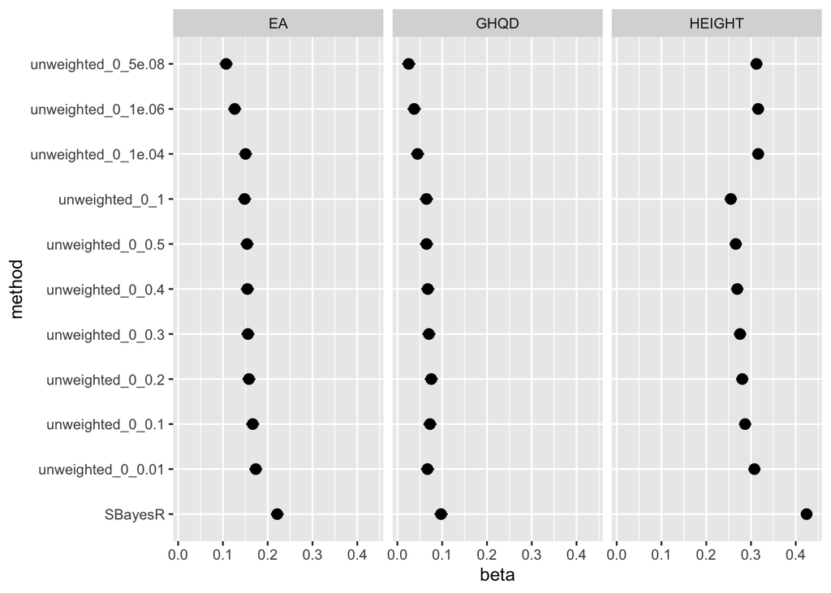

```r
library(lme4)
library(ggplot2)

phenos <- merge(height, ea, by = "IID", all = TRUE)
phenos <- merge(phenos, ghq_dep, by = "IID", all = TRUE)

phenos_prs <- merge(phenos, PRS, by = "IID")
phenos_prs <- merge(phenos_prs, fam, by = "IID")

phenos_prs_map <- c("HEIGHT" = "Height_Yengo2018",
                    "EA" = "EduYears_Lee2018",
                    "GHQD" = "MDD_Howard2019")
prs_methods <- c("SBayesR", paste0("unweighted_0_", c("5e.08", "1e.06", "1e.04", "0.01", "0.1", "0.2", "0.3", "0.4", "0.5", "1")))

pheno_prs_checks <- data.frame(pheno = rep(names(phenos_prs_map), times = length(prs_methods)),
                               method = rep(prs_methods, each = length(names(phenos_prs_map))),
                               beta = NA, se = NA)

for(i in seq.int(nrow(pheno_prs_checks))) {
  pheno <- pheno_prs_checks[i,"pheno"]
  method <- pheno_prs_checks[i,"method"]

  prs_predictor <- paste0(phenos_prs_map[[pheno]], "_", method)
  prs_formula <- as.formula(paste(pheno, "~", prs_predictor))
  m <- lmer(update(prs_formula, . ~ . + (1 | FID)), data = phenos_prs)
  m_summary <- summary(m)$coefficients
  b <- m_summary[prs_predictor,'Estimate']
  se <- m_summary[prs_predictor,'Std. Error']

  sd_predictor <- sd(phenos_prs[,prs_predictor], na.rm=T)
  sd_outcome <- sd(phenos_prs[,pheno], na.rm=T)

  b_std <- b * sd_predictor / sd_outcome
  se_std <- se * sd_predictor / sd_outcome

  pheno_prs_checks[i,"beta"] <- b_std
  pheno_prs_checks[i,"se"] <- se_std

}

ggplot(pheno_prs_checks, aes(x = method, y = beta, ymin = beta + qnorm(0.025, sd=se), ymax = beta + qnorm(0.975, sd=se))) + geom_pointrange() + facet_grid(~pheno) + coord_flip()
```

**2. Are the trio PGS_pcs and phenotypes correlated in the way we would expect?**

[figure not shown]

```r
# TRIO PGS correlations

trio_prs <- merge(trio, PRS, by="IID", all.x=T)
trio_prs <- merge(trio_prs, PRS, by.x = "MID", by.y = "IID", suffixes = c('', '_mat'))
trio_prs <- merge(trio_prs, PRS, by.x = "PID", by.y = "IID", suffixes = c('', '_pat'))


prs_mpo_cor <- data.frame(pheno = rep(names(phenos_prs_map), times = length(prs_methods)),
                               method = rep(prs_methods, each = length(names(phenos_prs_map))),
                               rMO = NA, rPO = NA, rMP = NA,
                               rMOlower = NA, rPOlower = NA, rMPlower = NA,
                               rMOupper = NA, rPOupper = NA, rMPupper = NA)

for(i in seq.int(nrow(pheno_prs_checks))) {
  pheno <- pheno_prs_checks[i,"pheno"]
  method <- pheno_prs_checks[i,"method"]

  prs_predictor <- paste0(phenos_prs_map[[pheno]], "_", method)
  prs_predictor_m <- paste0(prs_predictor, "_mat")
  prs_predictor_p <- paste0(prs_predictor, "_pat")

  rMO <- cor.test(trio_prs[,prs_predictor], trio_prs[,prs_predictor_m])
  rPO <- cor.test(trio_prs[,prs_predictor], trio_prs[,prs_predictor_p])
  rMP <- cor.test(trio_prs[,prs_predictor_m], trio_prs[,prs_predictor_p])

  prs_mpo_cor[i,"rMO"] <- rMO$estimate[['cor']]
  prs_mpo_cor[i,"rPO"] <- rPO$estimate[['cor']]
  prs_mpo_cor[i,"rMP"] <- rMP$estimate[['cor']]

  prs_mpo_cor[i,"rMOlower"] <- rMO$conf.int[1]
  prs_mpo_cor[i,"rPOlower"] <- rPO$conf.int[1]
  prs_mpo_cor[i,"rMPlower"] <- rMP$conf.int[1]

  prs_mpo_cor[i,"rMOupper"] <- rMO$conf.int[2]
  prs_mpo_cor[i,"rPOupper"] <- rPO$conf.int[2]
  prs_mpo_cor[i,"rMPupper"] <- rMP$conf.int[2]
}

# reshape
prs_mo_cor <- prs_mpo_cor[,c("pheno", "method", "rMO", "rMOlower", "rMOupper")]
prs_mo_cor$est <- "rMO"
prs_po_cor <- prs_mpo_cor[,c("pheno", "method", "rPO", "rPOlower", "rPOupper")]
prs_po_cor$est <- "rPO"
prs_mp_cor <- prs_mpo_cor[,c("pheno", "method", "rMP", "rMPlower", "rMPupper")]
prs_mp_cor$est <- "rMP"

names(prs_mo_cor)[3:5] <- names(prs_po_cor)[3:5] <- names(prs_mp_cor)[3:5] <- c("r", "r_upper", "r_lower")
prs_mp_cor_long <- rbind(prs_mo_cor, prs_po_cor, prs_mp_cor)

ggplot(prs_mp_cor_long, aes(x = method, y = r, ymin = r_lower, ymax = r_upper, color = est)) +
  geom_hline(yintercept = 0, colour = 'darkgray') +
  geom_hline(yintercept = 0.5, colour = 'darkgray') +
  geom_pointrange(position = position_dodge(width=0.3)) +
  facet_grid(~pheno) +
  coord_flip()
```

# Analysis Dataframe

PRS are scaled to the 1000G EUR reference group..  
All variables are pre-corrected for covariates, 20 offspring PCs, 20 maternal and paternal PCs, parental age, offspring age, offspring sex.